### Part I

#### Solution

Tuesday, November 19, 2013

**3.** Ku and Kulback (1974) reported on a data set collected to study coronary heart disease (*CHD*). A total of $1330$ patients were categorized with respect to blood pressure (*BP*) and serum cholesterol (*SC*) with ordinal categories as shown below:

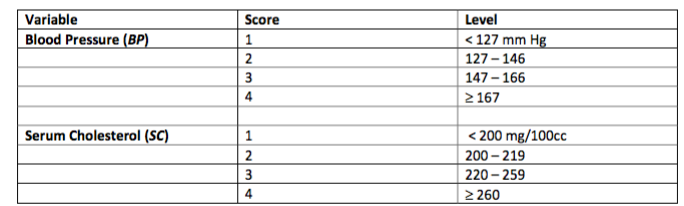

The data are in `CHD.txt`. The variable *CHD* is the number of patients contracting coronary heart disease and *total* is the total number of patients in the *SC* and *BP* combination.

The data are ine `CHD.txt`. Below are the variable names and the first few lines out of the 16 lines of data:

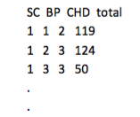

Use a logistic model for the probability of coronary heart disease (*CHD*) to answer the following:

```r
raw.text <- "
SC BP CHD total
1 1 2 119
1 2 3 124
1 3 3 50
1 4 4 31
2 1 3 88
2 2 2 100
2 3 1 44
2 4 3 23
3 1 8 127
3 2 11 220
3 3 6 74
3 4 6 49
4 1 7 74
4 2 12 111
4 3 11 57
4 4 11 44
"
chd.df <- read.table(header=TRUE, text=raw.text)
# SC and BP are ordinal variables - not nominal variables
# Do not convert as factor
```

1. Within the full model (including interaction term) conduct a hypothesis test for the effect of the interaction term. Show all steps of the hypothesis test.  
   **Solution**  
   $H_0: \beta_{SC \times BP} = 0$  
   $H_1: \beta_{SC \times BP} \neq 0$  
   T.S.: Wald test - $Z = \frac{\hat{\beta}}{SE_{\hat{\beta}}} \sim N(0,1)$

```r
# Data is presented in such a way that the input into `glm()` must be a matrix of success and failures
# Create a column that represents failures
chd.df$noCHD <- chd.df$total-chd.df$CHD

# Create matrix of successes and failures
chd.matrix <- as.matrix(chd.df[,c("CHD", "noCHD")])
head(chd.matrix)
```

```
##      CHD noCHD
## [1,]   2   117
## [2,]   3   121
## [3,]   3    47
## [4,]   4    27
## [5,]   3    85
## [6,]   2    98
```

```r
# equivalent to above, but w/o col names
#matrix(c(chd.df$CHD, chd.df$noCHD), ncol=2)

chd.glm <- glm(formula=chd.matrix ~ SC + BP + SC*BP, family=binomial(link=logit), data=chd.df)
summary(chd.glm)
```

```
##
## Call:
## glm(formula = chd.matrix ~ SC + BP + SC * BP, family = binomial(link = logit),
##     data = chd.df)
##
## Deviance Residuals:
##     Min       1Q   Median       3Q      Max
## -1.3373  -0.5997   0.3164   0.6382   0.9871
##
## Coefficients:
##             Estimate Std. Error z value Pr(>|z|)
## (Intercept) -5.81727    0.97127  -5.989 2.11e-09 ***
## SC           0.77092    0.30355   2.540   0.0111 *
## BP           0.74064    0.35287   2.099   0.0358 *
## SC:BP       -0.09826    0.11033  -0.891   0.3731
## ---
## Signif. codes:  0 '***' 0.001 '**' 0.01 '*' 0.05 '.' 0.1 ' ' 1
##
## (Dispersion parameter for binomial family taken to be 1)
##
##     Null deviance: 53.7181  on 15  degrees of freedom
## Residual deviance:  9.1256  on 12  degrees of freedom
## AIC: 70.235
##
## Number of Fisher Scoring iterations: 4
```

Conclusion: $Z=-.891$, *p*-value=0.3731. Fail to reject the null hypothesis. There is not enough evidence to suggest there is a significant interaction between the two variables.

2. Use backward elimination from the full model to select an appropriate model. Write down the selected theoretical model and the estimated logistic model. Write down the SAS code for fitting this model (write the SAS code clearly enough so that it could be run again).  
   **Solution**

```r
# Not sure how to use alpha for model selection for logistic regression
# Using AIC criteria
# Coincidentally matches answer
step(chd.glm, direction="backward")
```

```
## Start:  AIC=70.24
## chd.matrix ~ SC + BP + SC * BP
##
##         Df Deviance    AIC
## - SC:BP  1   9.9175 69.027
## <none>       9.1256 70.235
##
## Step:  AIC=69.03
## chd.matrix ~ SC + BP
##
##        Df Deviance    AIC
## <none>       9.917 69.027
## - BP    1   26.299 83.408
## - SC    1   33.319 90.429
```

```
##
## Call:  glm(formula = chd.matrix ~ SC + BP, family = binomial(link = logit),
##     data = chd.df)
##
## Coefficients:
## (Intercept)           SC           BP
##     -5.0702       0.5247       0.4414
##
## Degrees of Freedom: 15 Total (i.e. Null);  13 Residual
## Null Deviance:       53.72
## Residual Deviance: 9.917     AIC: 69.03
```

Interaction term is dropped. Final model: $\begin{align*} \log\left(\frac{\pi(x_{SC}, x_{BP})}{1 - \pi(x_{SC}, x_{BP})} \right) &= \beta_0 + \beta_{SC} \cdot x_{SC} + \beta_{BP} \cdot x_{BP} \\ \log\left(\frac{\hat{\pi}(x_{SC}, x_{BP})}{1 - \hat{\pi}(x_{SC}, x_{BP})} \right) &= -5.0702 + 0.5247 \cdot x_{SC} + 0.4414 \cdot x_{BP} \end{align*}$

```r
chd.final.glm <- glm(formula=chd.matrix ~ SC + BP, family=binomial(link=logit), data=chd.df)
confint(chd.final.glm)
```

```
##                  2.5 %     97.5 %
## (Intercept) -5.9666103 -4.2407113
## SC           0.3053909  0.7569193
## BP           0.2289527  0.6540557
```

That is, (0.229, 0.654).

4. Estimate the probability of *CHD* for a person with serum cholesterol of $225$ and blood pressure of $130$. Give a 95% confidence interval for this probability. Write down the SAS code you used.  
   **Solution**  
   The person described would be in SC group 3 and BP group 2. The estimated probability is

```r
# fitted probability
# relevant data is in 10th row
cbind(chd.df, fitted(chd.final.glm))[10,]
```

```
##    SC BP CHD total noCHD fitted(chd.final.glm)
## 10  3  2  11   220   209            0.06829003
```

That is, $\pi(x_{SC}=3, x_{BP}=2) = 0.0683$ A 95% confidence interval is

```r
# WARNING: The following gives CI for logit values but not correct
# Unclear how it is calculated
#cbind(chd.df, predict.glm(chd.final.glm, interval="prediction", level=0.50))[10,]

# 95% confidence interval
std.err <- predict(chd.final.glm, type="link", se.fit=TRUE)$se.fit[10]
E <- 1.96*std.err
fit.logit <- predict.lm(chd.final.glm)[10]
ci.logit <- fit.logit + c(-E, E)
exp(ci.logit)/(1 + exp(ci.logit))
```

```
##         10         10
## 0.05465669 0.08501817
```

5. Conditioning on serum cholesterol in group 4, find and report the conditional odds-ratio for blood pressure in group 1 versus blood pressure in group 2. What is the percentage decrease in odds of *CHD* for decreasing blood pressure from group 2 to group 1 given that serum cholesterol is in group 4?  
   **Solution**  
   The odds ratio is defined as $\theta = \frac{\text{odds}_1}{\text{odds}_2} = \frac{\pi_1/(1 - \pi_1)}{\pi/(1 - \pi_2)}$ The fitted values take the form $\log \left( \frac{\pi}{1 - \pi} \right)$, so we must exponentiate the fitted values to determine the odds.

```r
odds1 <- exp(predict.lm(chd.final.glm, newdata=data.frame(SC=4, BP=1)))
odds2 <- exp(predict.lm(chd.final.glm, newdata=data.frame(SC=4, BP=2)))
odds1/odds2
```

```
##         1
## 0.6431112
```

Conclusion: There is, conditioning on serum cholesterol group 4, about a 100% - 64% = 36% decrease in odds of CHD going from blood pressure group 2 to blood pressure group 1.